# Projeto de Capacidade Produtiva

Allan B. Martins

23 maio 2022

# Etapa V - Modelagem dos dados - 2012 a 2019 - **Y31D - OUTROS SERVIÇOS**

# Contextualização

O banco de dados analisado traz os dados de instrumentos , força de trabalho de instrumentos e despesa de custeio total da série temporal de **2012 a 2019** e utilizando por meio da **Regressão Linear Múltipla**, foi definido através de métrica **03 Conglomerados de Estados**, serão rodados 81 modelos de Regressão Linear Múltipla, ou seja, um modelo para cada conglomerado, para cada um dos 81 itens do Plano de Trabalho. Ao todo, serão 03 UF x 81 modelos, totalizando-se 243 modelos de regressão rodados, nessa primeira fase de modelagem o objetivo é entregar aos colegas do projeto, os resultados da saída **“summary”**, bem como as análises de resíduos [**testes de normalidade**, **testes de homocedasticidade**, **teste de independência dos resíduos**] e os respectivos **gráficos de resíduos**.

# 1 Definição de Conglomerados

## 1.1 Dendrograma Conglomerados

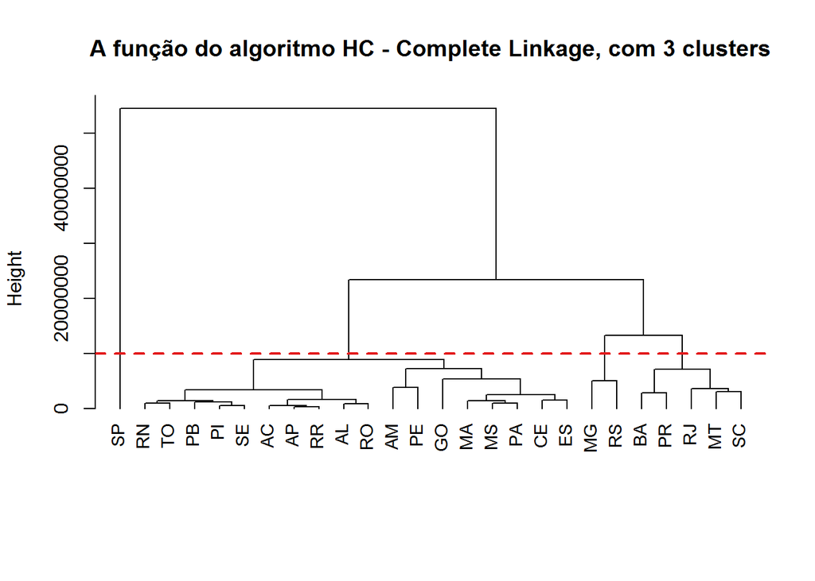

O **dendrograma** acima foi construído para facilitar a definição de **03 conglomerados de Estados** para uma melhor modelagem de dados, devido o Estado de **São Paulo** ser um **outlier**, ele foi incorporado no **conglomerado 3**, ficando a seguinte configuração dos conglomerados: **1 - (AC,AL,AP,PB,PI,RN,RO,RR,SE,TO)**, **2 - (AM,CE,ES,GO,MA,MS,PA,PE)** e **3 - (BA,MG,MT,PR,RJ,RS,SC,SP)**.

## 1.2 Boxplot Conglomerados

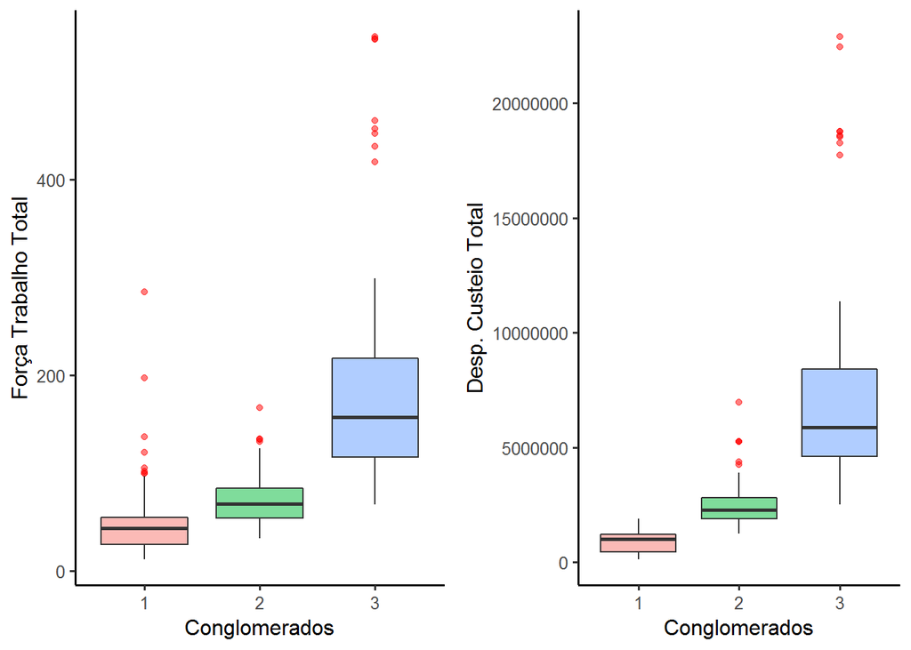

O **boxplot** acima foi construído com as variáveis **Força de trabalho Total** e **Desp. Custeio Total**, para uma melhor identificação de tamanho de cada conglomerado.

# 2 Análises por conglomerado

## 2.1 Conglomerado 1

```
## Rows: 80
## Columns: 5
## $ ANO        <dbl> 2012, 2012, 2012, 2012, 2012, 2012, 2012, 2012, 2012, 2012,~
## $ UF         <chr> "AC", "AL", "AP", "PB", "PI", "RN", "RO", "RR", "SE", "TO",~
## $ X1FTINST   <dbl> 6, 24, 11, 33, 19, 22, 16, 7, 27, 10, 6, 18, 10, 34, 24, 23~
## $ X2CusteioT <dbl> 533876.4, 1030769.6, 414760.7, 1204165.6, 1050301.0, 156146~
## $ Y31D       <dbl> 0, 135, 44, 305, 1880, 1288, 13, 39, 243, 19, 11, 430, 37, ~
```

| ANO | UF | FORÇA DE TRABALHO PERIÓDICA | DESPESA DE CUSTEIO | OUTROS SERVIÇOS |
| --- | --- | --- | --- | --- |
| 2012 | AC | 6 | 533876.4 | 0 |
| 2012 | AL | 24 | 1030769.6 | 135 |
| 2012 | AP | 11 | 414760.7 | 44 |
| 2012 | PB | 33 | 1204165.6 | 305 |
| 2012 | PI | 19 | 1050301.0 | 1880 |
| 2012 | RN | 22 | 1561464.8 | 1288 |
| 2012 | RO | 16 | 1066101.1 | 13 |
| 2012 | RR | 7 | 363277.0 | 39 |

### 2.1.1 A UF (**AC, AL, AP, PB, PI, RN, RO, RR, SE, TO**) e o item do Plano de trabalho (**Y31D - OUTROS SERVIÇOS**) que estão sendo analisados nos teste a seguir.

#### 2.1.1.1 Ajustar o modelo linear com intercepto

##### 2.1.1.1.1 Estatística de descritivas

```r
options(scipen=999)
Mod1<-lm(Y31D~X1FTINST+X2CusteioT, bdcp_2012_2019_1) #Ajustar o modelo linear com intercepto
summary(Mod1)   #Obter as estatísticas descritivas do modelo ajustado
```

```
##
## Call:
## lm(formula = Y31D ~ X1FTINST + X2CusteioT, data = bdcp_2012_2019_1)
##
## Residuals:
##     Min      1Q  Median      3Q     Max
## -587.65 -324.79 -101.52  -33.48 1829.70
##
## Coefficients:
##                Estimate  Std. Error t value Pr(>|t|)
## (Intercept)  -0.2968362 133.9577457  -0.002    0.998
## X1FTINST     -1.0999115   2.4604074  -0.447    0.656
## X2CusteioT    0.0003414   0.0001293   2.640    0.010 *
## ---
## Signif. codes:  0 '***' 0.001 '**' 0.01 '*' 0.05 '.' 0.1 ' ' 1
##
## Residual standard error: 541.3 on 77 degrees of freedom
## Multiple R-squared:  0.08416,    Adjusted R-squared:  0.06038
## F-statistic: 3.538 on 2 and 77 DF,  p-value: 0.03388
```

#### 2.1.1.2 Gráfico de dispersão

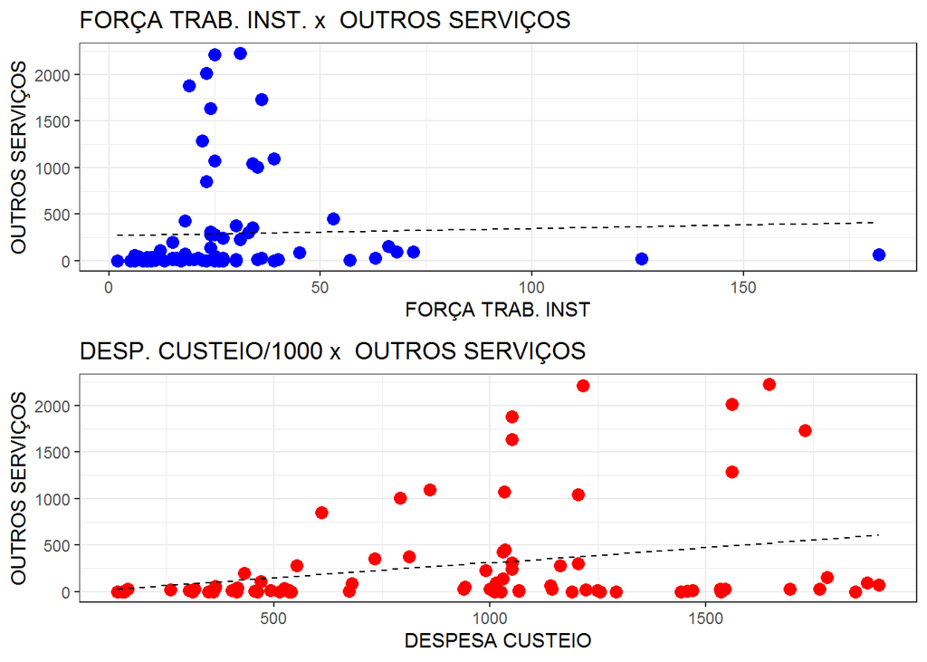

#### 2.1.1.3 Proceder à análise de resíduos

##### 2.1.1.3.1 Gráfico de resíduos

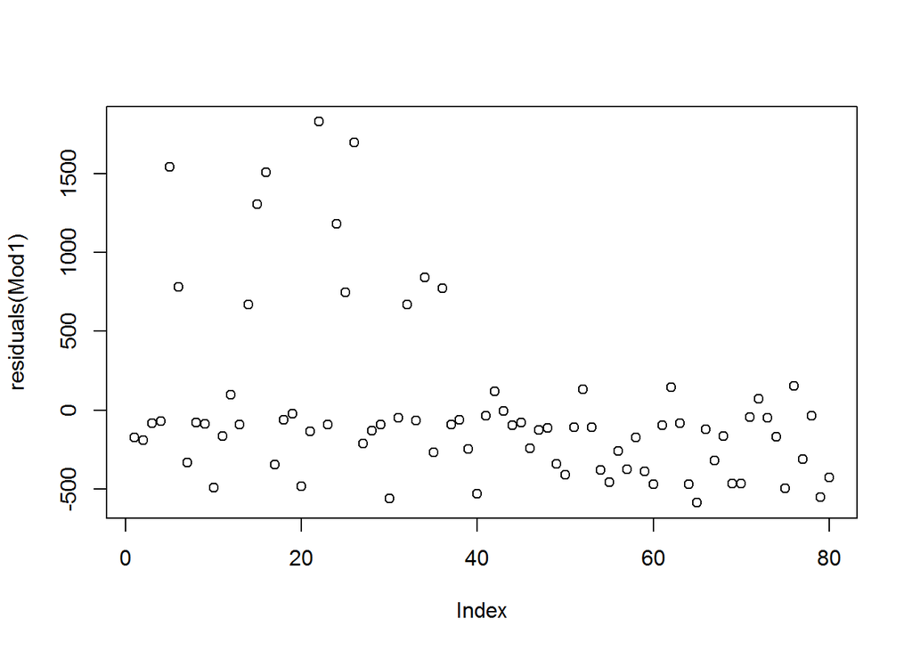

#### 2.1.1.4 Testar normalidade dos resíduos

```r
shapiro.test(residuals(Mod1))
```

```
##
##  Shapiro-Wilk normality test
##
## data:  residuals(Mod1)
## W = 0.758, p-value = 0.0000000003704
```

#### 2.1.1.5 Teste de homocedasticidade:

##### 2.1.1.5.1 Teste de Goldefeld-Quandt

```r
gqtest(Mod1)
```

```
##
##  Goldfeld-Quandt test
##
## data:  Mod1
## GQ = 0.039995, df1 = 37, df2 = 37, p-value = 1
## alternative hypothesis: variance increases from segment 1 to 2
```

##### 2.1.1.5.2 Teste de independência dos resíduos

```r
dwtest(Mod1)
```

```
##
##  Durbin-Watson test
##
## data:  Mod1
## DW = 1.427, p-value = 0.00406
## alternative hypothesis: true autocorrelation is greater than 0
```

##### 2.1.1.5.3 Gráfico para avaliar os resíduos

###### 2.1.1.5.3.1 Análise gráfica

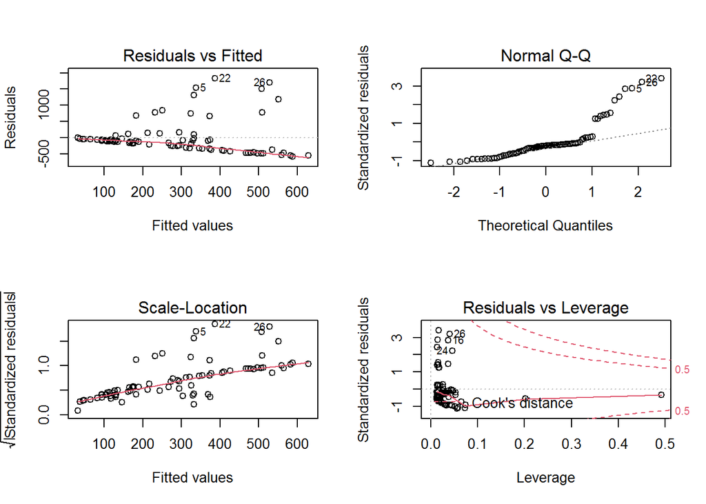

##### 2.1.1.5.4 Gráfico do observado (y) versus predito

[figure not shown]

##### 2.1.1.5.5 Agregar os resultados no data.frame

| Força de Trabalho | Custeio Total | OUTROS SERVIÇOS | Mod1.fitted.values | Mod1.residual |
| --- | --- | --- | --- | --- |
| 6 | 533876.4 | 0 | 175.3759 | -175.37594 |
| 24 | 1030769.6 | 135 | 325.2232 | -190.22320 |
| 11 | 414760.7 | 44 | 129.2087 | -85.20872 |
| 33 | 1204165.6 | 305 | 374.5236 | -69.52361 |
| 19 | 1050301.0 | 1880 | 337.3910 | 1542.60896 |
| 22 | 1561464.8 | 1288 | 508.6091 | 779.39087 |
| 16 | 1066101.1 | 13 | 346.0851 | -333.08511 |
| 7 | 363277.0 | 39 | 116.0312 | -77.03119 |

## 2.2 Conglomerado 2

```
## Rows: 64
## Columns: 5
## $ ANO        <dbl> 2012, 2012, 2012, 2012, 2012, 2012, 2012, 2012, 2013, 2013,~
## $ UF         <chr> "AM", "CE", "ES", "GO", "MA", "MS", "PA", "PE", "AM", "CE",~
## $ X1FTINST   <dbl> 21, 51, 34, 65, 40, 31, 30, 33, 30, 50, 33, 69, 40, 36, 30,~
## $ X2CusteioT <dbl> 1975885, 2116469, 2180463, 5257209, 2320830, 3049246, 24822~
## $ Y31D       <dbl> 4232, 319, 126, 6761, 237, 21872, 1192, 431, 4106, 590, 79,~
```

| ANO | UF | FORÇA DE TRABALHO PERIÓDICA | DESPESA DE CUSTEIO | OUTROS SERVIÇOS |
| --- | --- | --- | --- | --- |
| 2012 | AM | 21 | 1975885 | 4232 |
| 2012 | CE | 51 | 2116469 | 319 |
| 2012 | ES | 34 | 2180463 | 126 |
| 2012 | GO | 65 | 5257209 | 6761 |
| 2012 | MA | 40 | 2320830 | 237 |
| 2012 | MS | 31 | 3049246 | 21872 |
| 2012 | PA | 30 | 2482231 | 1192 |
| 2012 | PE | 33 | 3495898 | 431 |

### 2.2.1 A UF (**AM, CE, ES, GO, MA, MS, PA, PE**) e o item do Plano de trabalho (**Y31D - OUTROS SERVIÇOS**) que estão sendo analisados nos teste a seguir.

#### 2.2.1.1 Ajustar o modelo linear com intercepto

##### 2.2.1.1.1 Estatística de descritivas

```r
options(scipen=999)
Mod2<-lm(Y31D~X1FTINST+X2CusteioT, bdcp_2012_2019_2) #Ajustar o modelo linear com intercepto
summary(Mod2)   #Obter as estatísticas descritivas do modelo ajustado
```

```
##
## Call:
## lm(formula = Y31D ~ X1FTINST + X2CusteioT, data = bdcp_2012_2019_2)
##
## Residuals:
##     Min      1Q  Median      3Q     Max
## -5180.0 -1631.7  -946.1   184.2 19062.0
##
## Coefficients:
##                 Estimate   Std. Error t value Pr(>|t|)
## (Intercept)  -57.0629935 1520.7051414  -0.038   0.9702
## X1FTINST     -27.0151083   31.0384742  -0.870   0.3875
## X2CusteioT     0.0012149    0.0005119   2.374   0.0208 *
## ---
## Signif. codes:  0 '***' 0.001 '**' 0.01 '*' 0.05 '.' 0.1 ' ' 1
##
## Residual standard error: 4009 on 61 degrees of freedom
## Multiple R-squared:  0.08464,    Adjusted R-squared:  0.05463
## F-statistic:  2.82 on 2 and 61 DF,  p-value: 0.06739
```

#### 2.2.1.2 Gráfico de dispersão

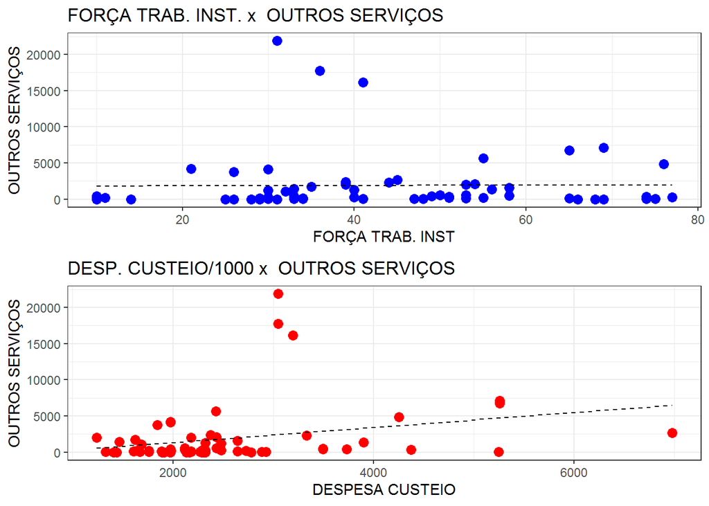

#### 2.2.1.3 Proceder à análise de resíduos

##### 2.2.1.3.1 Gráfico de resíduos

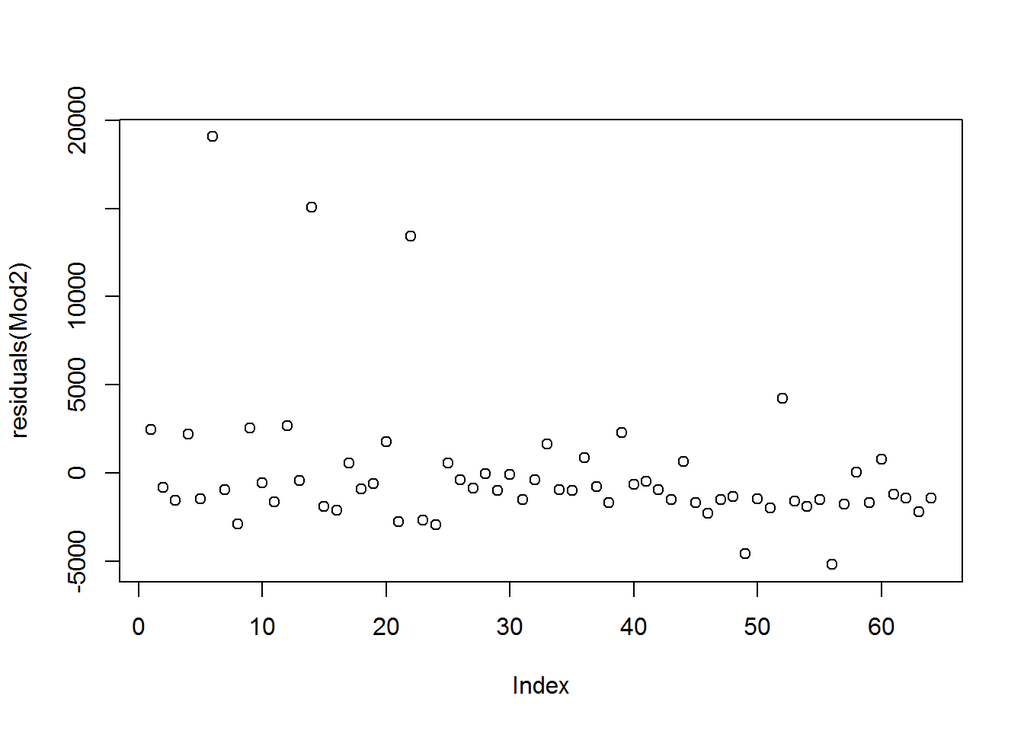

#### 2.2.1.4 Testar normalidade dos resíduos

```r
shapiro.test(residuals(Mod2))
```

```
##
##  Shapiro-Wilk normality test
##
## data:  residuals(Mod2)
## W = 0.60896, p-value = 0.000000000008769
```

#### 2.2.1.5 Teste de homocedasticidade:

##### 2.2.1.5.1 Teste de Goldefeld-Quandt

```r
gqtest(Mod2)
```

```
##
##  Goldfeld-Quandt test
##
## data:  Mod2
## GQ = 0.073265, df1 = 29, df2 = 29, p-value = 1
## alternative hypothesis: variance increases from segment 1 to 2
```

##### 2.2.1.5.2 Teste de independência dos resíduos

```r
dwtest(Mod2)
```

```
##
##  Durbin-Watson test
##
## data:  Mod2
## DW = 2.2697, p-value = 0.8641
## alternative hypothesis: true autocorrelation is greater than 0
```

##### 2.2.1.5.3 Gráfico para avaliar os resíduos

###### 2.2.1.5.3.1 Análise gráfica

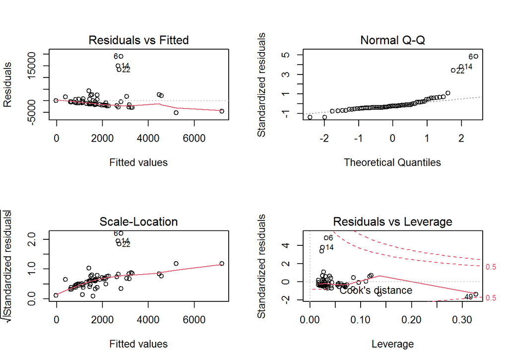

##### 2.2.1.5.4 Gráfico do observado (y) versus predito

[figure not shown]

##### 2.2.1.5.5 Agregar os resultados no data.frame

| Força de Trabalho | Custeio Total | OUTROS SERVIÇOS | Mod2.fitted.values | Mod2.residual |
| --- | --- | --- | --- | --- |
| 21 | 1975885 | 4232 | 1776.098 | 2455.9023 |
| 51 | 2116469 | 319 | 1136.439 | -817.4390 |
| 34 | 2180463 | 126 | 1673.441 | -1547.4410 |
| 65 | 5257209 | 6761 | 4573.873 | 2187.1272 |
| 40 | 2320830 | 237 | 1681.880 | -1444.8801 |
| 31 | 3049246 | 21872 | 2809.960 | 19062.0404 |
| 30 | 2482231 | 1192 | 2148.116 | -956.1159 |
| 33 | 3495898 | 431 | 3298.562 | -2867.5618 |

## 2.3 Conglomerado 3

```
## Rows: 64
## Columns: 5
## $ ANO        <dbl> 2012, 2012, 2012, 2012, 2012, 2012, 2012, 2012, 2013, 2013,~
## $ UF         <chr> "BA", "MG", "MT", "PR", "RJ", "RS", "SC", "SP", "BA", "MG",~
## $ X1FTINST   <dbl> 95, 150, 46, 105, 138, 148, 71, 287, 81, 144, 50, 96, 159, ~
## $ X2CusteioT <dbl> 6887926, 10378050, 4868475, 6281903, 4996668, 10377040, 337~
## $ Y31D       <dbl> 3047, 9062, 10422, 175, 4794, 6819, 2128, 31673, 3456, 1129~
```

| ANO | UF | FORÇA DE TRABALHO PERIÓDICA | DESPESA DE CUSTEIO | OUTROS SERVIÇOS |
| --- | --- | --- | --- | --- |
| 2012 | BA | 95 | 6887926 | 3047 |
| 2012 | MG | 150 | 10378050 | 9062 |
| 2012 | MT | 46 | 4868475 | 10422 |
| 2012 | PR | 105 | 6281903 | 175 |
| 2012 | RJ | 138 | 4996668 | 4794 |
| 2012 | RS | 148 | 10377040 | 6819 |
| 2012 | SC | 71 | 3375619 | 2128 |
| 2012 | SP | 287 | 18775593 | 31673 |

### 2.3.1 A UF (**BA, MG, MT, PR, RJ, RS, SC, SP**) e o item do Plano de trabalho (**Y31D - OUTROS SERVIÇOS**) que estão sendo analisados nos teste a seguir.

#### 2.3.1.1 Ajustar o modelo linear com intercepto

##### 2.3.1.1.1 Estatística de descritivas

```r
options(scipen=999)
Mod3<-lm(Y31D~X1FTINST+X2CusteioT, bdcp_2012_2019_3) #Ajustar o modelo linear com intercepto
summary(Mod3)   #Obter as estatísticas descritivas do modelo ajustado
```

```
##
## Call:
## lm(formula = Y31D ~ X1FTINST + X2CusteioT, data = bdcp_2012_2019_3)
##
## Residuals:
##     Min      1Q  Median      3Q     Max
## -9979.1 -2598.6  -588.3  1764.7 22880.8
##
## Coefficients:
##                 Estimate   Std. Error t value Pr(>|t|)
## (Intercept)  -36.4017243 1239.2224416  -0.029   0.9767
## X1FTINST     -16.6211727   17.3037896  -0.961   0.3406
## X2CusteioT     0.0007243    0.0002960   2.447   0.0173 *
## ---
## Signif. codes:  0 '***' 0.001 '**' 0.01 '*' 0.05 '.' 0.1 ' ' 1
##
## Residual standard error: 5304 on 61 degrees of freedom
## Multiple R-squared:  0.1796, Adjusted R-squared:  0.1527
## F-statistic: 6.676 on 2 and 61 DF,  p-value: 0.002389
```

#### 2.3.1.2 Gráfico de dispersão

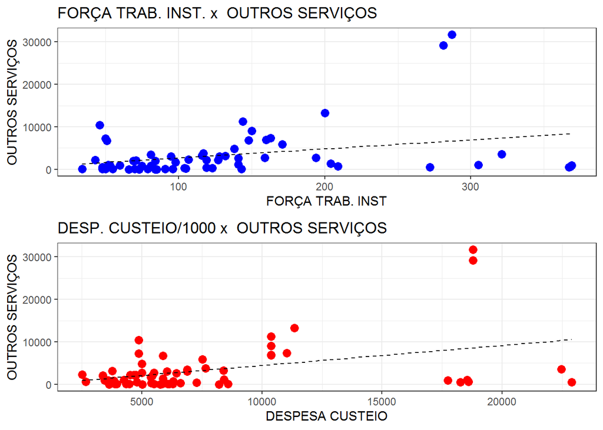

#### 2.3.1.3 Proceder à análise de resíduos

##### 2.3.1.3.1 Gráfico de resíduos

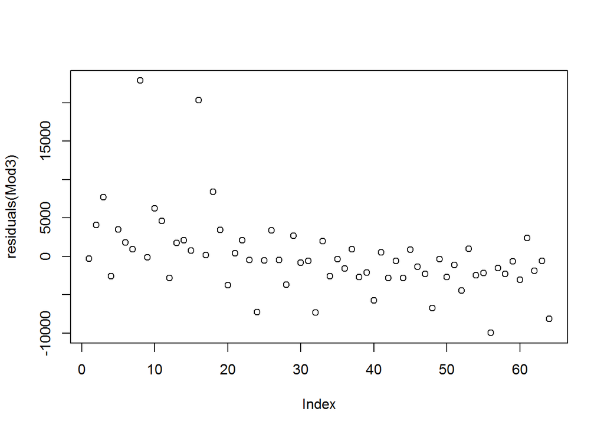

#### 2.3.1.4 Testar normalidade dos resíduos

```r
shapiro.test(residuals(Mod3))
```

```
##
##  Shapiro-Wilk normality test
##
## data:  residuals(Mod3)
## W = 0.80932, p-value = 0.0000001162
```

#### 2.3.1.5 Teste de homocedasticidade:

##### 2.3.1.5.1 Teste de Goldefeld-Quandt

```r
gqtest(Mod3)
```

```
##
##  Goldfeld-Quandt test
##
## data:  Mod3
## GQ = 0.01251, df1 = 29, df2 = 29, p-value = 1
## alternative hypothesis: variance increases from segment 1 to 2
```

##### 2.3.1.5.2 Teste de independência dos resíduos

```r
dwtest(Mod3)
```

```
##
##  Durbin-Watson test
##
## data:  Mod3
## DW = 1.8063, p-value = 0.2246
## alternative hypothesis: true autocorrelation is greater than 0
```

##### 2.3.1.5.3 Gráfico para avaliar os resíduos

###### 2.3.1.5.3.1 Análise gráfica

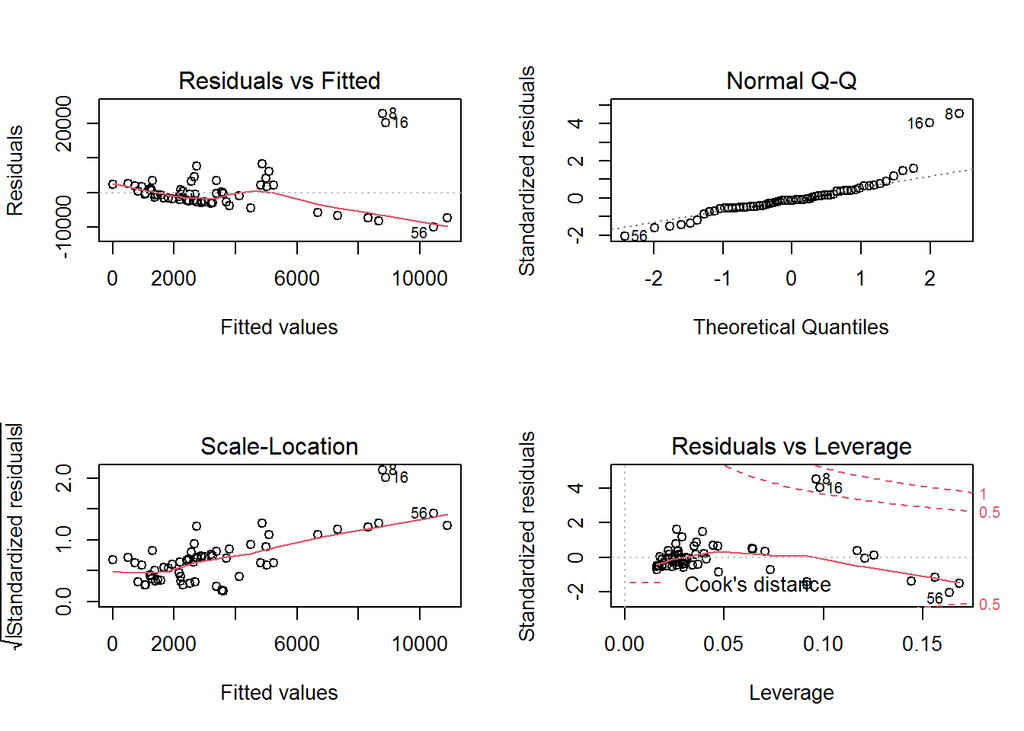

##### 2.3.1.5.4 Gráfico do observado (y) versus predito

[figure not shown]

##### 2.3.1.5.5 Agregar os resultados no data.frame

| Força de Trabalho | Custeio Total | OUTROS SERVIÇOS | Mod3.fitted.values | Mod3.residual |
| --- | --- | --- | --- | --- |
| 95 | 6887926 | 3047 | 3373.394 | -326.3942 |
| 150 | 10378050 | 9062 | 4987.067 | 4074.9328 |
| 46 | 4868475 | 10422 | 2725.178 | 7696.8221 |
| 105 | 6281903 | 175 | 2768.251 | -2593.2507 |
| 138 | 4996668 | 4794 | 1288.878 | 3505.1220 |
| 148 | 10377040 | 6819 | 5019.578 | 1799.4220 |
| 71 | 3375619 | 2128 | 1228.399 | 899.6014 |
| 287 | 18775593 | 31673 | 8792.164 | 22880.8361 |

# 3 Diversos

## 3.1 Créditos - Participantes do Projeto Capacidade Produtiva:

**MEMBROS DO PROJETO**  
Allan Batista Martins,  
##

## 3.2 Material de Apoio

- Criando dendogramas com o R: [Fabio Machry](http://rstudio-pubs-static.s3.amazonaws.com/311400_8b041824d53046b89952fae6a60ace3b.html)
- Regressão linear múltipla no R: [Fernanda Peres](https://youtu.be/4YLOwyx_hxo)
- PLAYLIST - Criando gráficos no R com o ggplot2 (Parte 1 ao 2): [Fernanda Peres](https://youtu.be/DYsPRa3vpf0)
- PLAYLIST - R Markdown: Gerando relatórios usando o R (Parte 1 ao 5): [Fernanda Peres](https://youtu.be/obxa5VH4WvY)
- Minicurso R - UFPR: [UFPR](https://youtu.be/obxa5VH4WvY)
- R Markdown: The Definitive Guide: [Yihui Xie, J. J. Allaire, Garrett Grolemund](https://bookdown.org/yihui/rmarkdown/)